# Analyzing health index by behavioral and environmental characteristics of U.S. counties

**Adelyn Chen**  
Prepared for Univ. of Pennsylvania Wharton - STAT 477  
Professor Richard Waterman  
March 16, 2022

# Key Questions

1. Which predictors are most *strongly associated* with a county's health index?
2. Will behavioral and/or environmental health characteristics *better account* for the variation in county health index than simply those predictors that are most strongly correlated with the health index?
3. On a broader scale, how well can these characteristics *predict* the county's health index?
4. Given the structure of the data and models, are *linear regression models* or *trees* more effective in accounting for variation?

## Dependent Variable: Health Index

- This data is presented as the proportion of people in a county who have poor health.
- Lower proportions indicate a healthier county, and vice versa.
- Below is a histogram of the health indices across all counties.

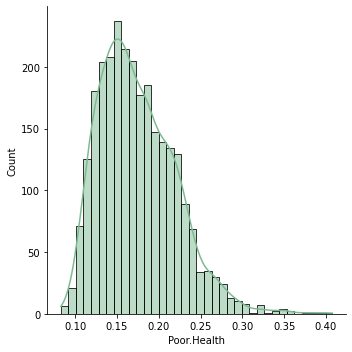

```python
sns.displot(county_data['Poor.Health'], kde=True);
```

## Distribution of Health Index

- Roughly right skewed
- Mean of 0.174
  - On average, 17.4% of residents in a county have poor health.

### Notable Locations

- 4 of the 5 healthiest counties are concentrated in the Central U.S. (Colorado, Kansas, South Dakota (2)), and the remaining county is in Connecticut.
- 4 of the 5 unhealthiest counties are in Texas.

## Health Index by State

- Although only one of the top 5 healthiest counties is in Connecticut, on average Connecticut is the healthiest state.
- By contrast, although 4 of the 5 unhealthiest counties are in Texas, on average Texas is only the 12th unhealthiest state.

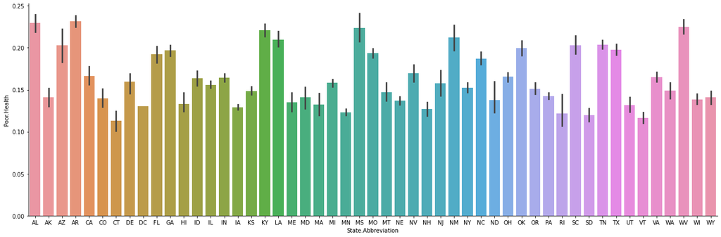

```python
sns.catplot(x = 'State.Abbreviation', y = 'Poor.Health', data = county_data,
            kind = 'bar', height = 6, aspect = 3);
```

# Correlations Between Variables

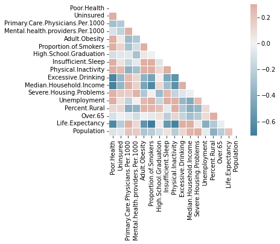

```python
# Correlation Heatmap
sns.heatmap(cm, mask=mask, cmap=cmap, vmax=.3, center=0, square=True, linewidths=1);
```

- Based on the correlation heatmap, **Excessive Drinking, Median Household Income, and Life Expectancy** have stronger correlation with **Poor Health** than other predictors.
- As expected, Proportion of Smokers and Physical Inactivity are both negatively correlated with Life Expectancy.
- Proportion of Smokers is also negatively correlated with Median Household Income.

Now that we know how some of the predictors are correlated with the health index, let's take a closer look at the predictors with the strongest correlation.

## Excessive Drinking

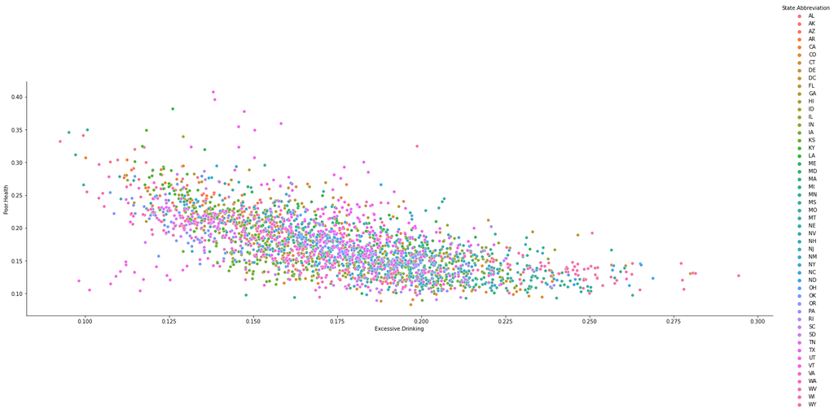

```python
sns.relplot(x='Excessive.Drinking', y='Poor.Health', data=county_data,
            hue='State.Abbreviation', height = 7, aspect = 3);
```

The overall relationship between Poor Health and Excessive Drinking looks roughly linear, but the impact of Excessive Drinking seems to vary by state.

## Median Household Income

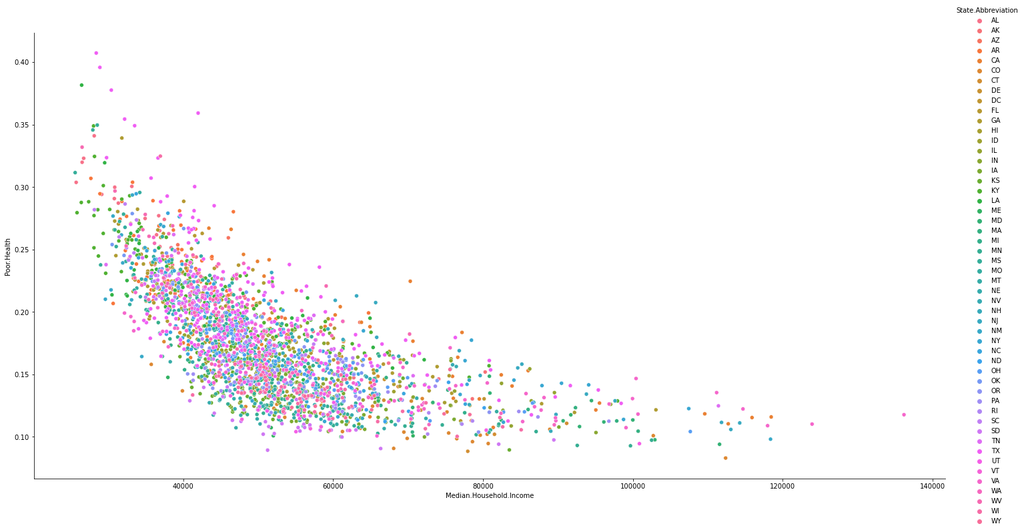

```python
sns.relplot(x='Median.Household.Income', y='Poor.Health', data=county_data,
            hue='State.Abbreviation', height = 10, aspect = 2);
```

Here the relationship looks more curved than linear; it might be wise to do a log transform.

### Log Transform

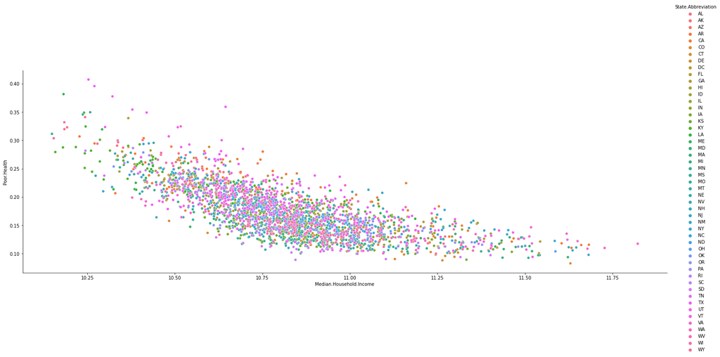

```python
sns.relplot(x=np.log(county_data['Median.Household.Income']), y='Poor.Health', data=county_data,
            hue='State.Abbreviation', height = 7, aspect = 3);
```

```python
print(np.corrcoef(county_data['Median.Household.Income'], county_data['Poor.Health']))
print(np.corrcoef(np.log(county_data['Median.Household.Income']),
                  county_data['Poor.Health']))
```

```
[[ 1.        -0.6801463]
 [-0.6801463  1.       ]]
[[ 1.         -0.74541546]
 [-0.74541546  1.        ]]
```

## Life Expectancy

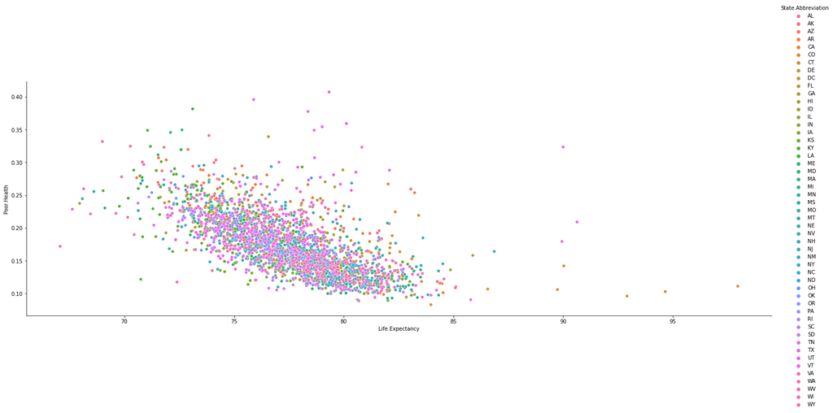

```python
sns.relplot(x='Life.Expectancy', y='Poor.Health', data=county_data,
            hue='State.Abbreviation', height = 7, aspect = 3);
```

Similar to Excessive Drinking, the overall relationship between Poor Health and Life Expectancy looks roughly linear. However, there is extra "noise" of points that fall outside of the expected range; this predictor may not be as useful in multiple regression.

## Correlation Between *Predictors*

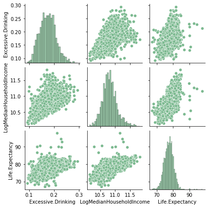

```python
sns.pairplot(county_data[['Excessive.Drinking','LogMedianHouseholdIncome','Life.Expectancy']], height = 2);
```

The three predictors are roughly positively correlated among each other, but the visual scatter indicates that more analysis by state might be necessary before determining whether an interaction term should be used in the regression model.

### Correlation Between Behavioral Characteristics

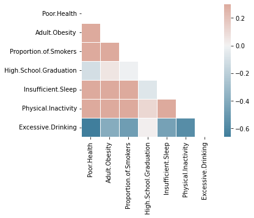

```python
# Correlation Heatmap - Behavioral Predictors
cm_b = county_data_behavioral.corr()
mask_b = np.triu(np.ones_like(cm_b, dtype=bool))
cmap = sns.diverging_palette(230, 20, as_cmap=True)
sns.heatmap(cm_b, mask=mask_b, cmap=cmap, vmax=.3, center=0, square=True, linewidths=1);
```

Excessive Drinking has some correlation with the other behavioral predictors, except for high school graduation. It is most highly correlated with physical inactivity.

### Correlation Between Environmental Characteristics

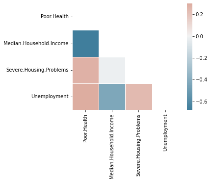

```python
# Correlation Heatmap - Environmental Predictors
cm_e = county_data_environmental.corr()
mask_e = np.triu(np.ones_like(cm_e, dtype=bool))
cmap = sns.diverging_palette(230, 20, as_cmap=True)
sns.heatmap(cm_e, mask=mask_e, cmap=cmap, vmax=.3, center=0, square=True, linewidths=1);
```

Median Household Income has some correlation with Unemployment, which is a logical conclusion.

# Linear Regression Models

We will run 3 linear regression models for comparison; for simplicity, the actual regression outputs have been omitted. All included predictors are continuous.

### Model 1: Correlated Predictors

- Log of Median Household Income
- Excessive Drinking

### Model 2: Behavioral Health Determinants

- Adult Obesity
- Proportion of Smokers
- High School Graduation
- Insufficient Sleep
- Physical Inactivity
- Excessive Drinking

### Model 3: Environmental Health Determinants

- Median Household Income (we will continue to use the log)
- Severe Housing Problems
- Unemployment

## Model Metric Comparison

| **Model #** | **Characteristics** | **R-squared** | **% P-values < 0.05** | **Condition Number** |
| --- | --- | --- | --- | --- |
| 1 | Correlated | 0.636 | 100 | 1.52e+04 |
| 2 | Behavioral | 0.687 | 100 | 74.4 |
| 3 | Environmental | 0.639 | 100 | 908 |

- Although all 3 models have similar R-squared values and all predictors are statistically significant, Model 2 (Behavioral Characteristics) has the highest R-squared and the lowest condition number, indicating lower possibility of multicollinearity issues.
- As such, based on these metrics, of these 3 regression models, the **Behavioral model** best accounts for the variation in the dependent variable.
- Caveat: There may be other models combining correlated, behavioral, and environmental characteristics that are more "effective".
- Now we'll move on to assessing the models' predictive ability.

## Train and Test Splits

```python
from sklearn.model_selection import train_test_split
from sklearn.linear_model import LinearRegression

# Define variables
X1 = county_data[['LogMedianHouseholdIncome','Excessive.Drinking']]
y = county_data['Poor.Health']

# Split the data into train and test
X1_train, X1_test, y_train, y_test = train_test_split(X1, y, test_size = 0.3, random_state=1940)

# Fit
clf = LinearRegression()
clf.fit(X1_train,y_train)

# Predict and score accuracy (%)
clf.predict(X1_test)
print(clf.score(X1_test,y_test))
```

```
0.6654120454914023
```

| **Model #** | **Characteristics** | **Prediction Accuracy** |
| --- | --- | --- |
| 1 | Correlated | 66.54% |
| 2 | Behavioral | 70.35% |
| 3 | Environmental | 59.40% |

The second model has the most accurate predictions, which corroborates the earlier regression metric analysis.

# Tree Regression Models

```
0.5841003044340856
```

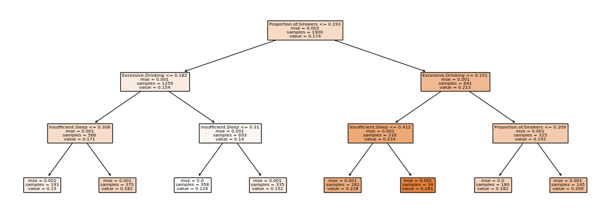

```python
# Simple Tree Based on Behavioral Characteristics
fig = plt.figure(num=None, figsize = (17,6), dpi = 80, facecolor = "w", edgecolor = "k")
tree.plot_tree(regtree, feature_names = X2.columns, filled=True);
print(regtree.score(X2_test, y_test))
```

This simple tree accounts for 58.41% of the variation in Health Index. Would a tree with cost-complexity pruning account for more of the variation in Health Index than the behavioral linear regression model?

## Modeling with Cost Complexity Pruning

```
0.5344079725678343
```

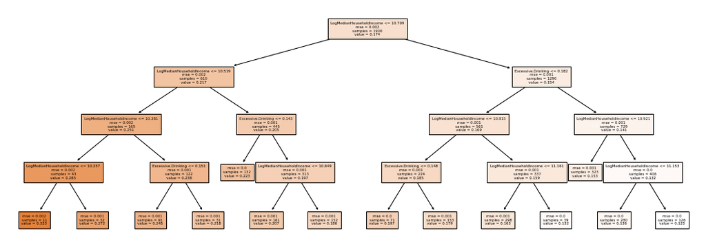

```python
# Correlation (Model 1)
print(test_scores[best1]) # R-square of best tree
fig = plt.figure(num=None, figsize = (17,6), dpi = 80, facecolor = "w", edgecolor = "k")
tree.plot_tree(rgrs1[best1], feature_names = X1.columns, filled=True, fontsize = 5);
# The same analysis is run for the other two models as well, but for simplicity they are
# not displayed. Results are summarized.
```

## R-square Comparison

[output not shown]

## Variable Importance By Tree

```python
# Tree 1
print(importances1)
```

```
                    Feature  Importance
0  LogMedianHouseholdIncome       0.867
1        Excessive.Drinking       0.133
```

```python
# Tree 2
print(importances2)
```

```
                  Feature  Importance
1   Proportion.of.Smokers       0.629
5      Excessive.Drinking       0.239
3      Insufficient.Sleep       0.119
4     Physical.Inactivity       0.013
0           Adult.Obesity       0.000
2  High.School.Graduation       0.000
```

```python
# Tree 3
print(importances3)
```

```
                   Feature  Importance
0  Median.Household.Income       0.889
2             Unemployment       0.057
1  Severe.Housing.Problems       0.054
```

Based on the analysis of variable importance for all 3 trees, the most important predictor is **Median Household Income**; the log of Median Household Income has an importance of 0.867 in Tree 1 and 0.889 in Tree 3. By contrast, the most important predictor in Tree 2 is Proportion of Smokers, which only has an importance of 0.629.

# Conclusions

## Suggestions for Further Analysis

1. Because the R-square and prediction accuracy values generated by some of the models are quite similar, one approach would be to regenerate prediction values with different random seeds and train/test split proportions.
2. Observing other predictors and how they vary by state may also provide insight into improving the tree models.
3. In further analysis, addressing some of the multicollinearity between related predictors may improve prediction accuracy.